# Tutorial 12 - Machine Learning

SFR 605

# Load libraries

```
## here() starts at C:/Users/sande/OneDrive/Desktop/Code/SFR605
```

# Introduction

The aim of this tutorial is to introduce machine learning methods for ecological prediction, with a focus on random forests and model interpretation. We will use soil carbon data from the National Ecological Observatory Network (NEON) to predict soil organic carbon (SOC) concentration from environmental and soil predictors. Along the way we will compare our ML model to the linear mixed models covered earlier in the course and learn to interpret black-box predictions using Shapley values.

`patchwork` lets you combine ggplot objects using `+` for side-by-side layouts and `/` for stacked layouts. We will use it throughout to compare plots. For example:

```
p1 + p2                          ## side by side
p1 / p2                          ## stacked
p1 + p2 + plot_annotation(title = "My combined figure")
```

# Load and explore the data

```r
soc_data <- read_csv("data/neon_soil_soc.csv")
glimpse(soc_data)
```

```
## Rows: 219
## Columns: 11
## $ site_id      <chr> "ABBY", "ABBY", "ABBY", "ABBY", "BARR", "BARR", "BARR", "…
## $ pit_id       <chr> "D16_ABBY_PIT1", "D16_ABBY_PIT1", "D16_ABBY_PIT1", "D16_A…
## $ horizon      <chr> "A", "A", "B", "O", "O", "O", "O", "A", "B", "B", "B", "B…
## $ depth_top    <dbl> 3, 19, 44, 0, 7, 58, 0, 3, 40, 9, 15, 22, 0, 2, 14, 23, 5…
## $ depth_bottom <dbl> 19, 44, 74, 3, 32, 110, 7, 5, 73, 15, 22, 40, 3, 14, 23, …
## $ soc_pct      <dbl> 128, 49, 22, 138, 246, 88, 396, 386, 9, 38, 27, 13, 448, …
## $ mat_c        <dbl> 0.8509, 0.8509, 0.8509, 0.8509, -1.1906, -1.1906, -1.1906…
## $ map_mm       <dbl> 2447, 2447, 2447, 2447, 112, 112, 112, 1258, 1258, 1258, …
## $ clay_pct     <dbl> 37.4, 34.9, 42.8, 36.4, NA, 19.5, NA, 6.2, 1.6, 3.6, 3.8,…
## $ sand_pct     <dbl> 26.8, 24.8, 20.1, 27.2, NA, 53.4, NA, 46.8, 71.5, 61.8, 6…
## $ bulk_density <dbl> 0.3933, 0.8475, 0.8913, 0.1602, 0.3050, 0.3525, NA, 0.165…
```

```r
summary(soc_data)
```

```
##    site_id             pit_id            horizon            depth_top
##  Length:219         Length:219         Length:219         Min.   :  0.00
##  Class :character   Class :character   Class :character   1st Qu.:  2.50
##  Mode  :character   Mode  :character   Mode  :character   Median : 21.00
##                                                           Mean   : 34.97
##                                                           3rd Qu.: 55.00
##                                                           Max.   :185.00
##
##   depth_bottom      soc_pct          mat_c             map_mm
##  Min.   :  1.0   Min.   :  0.0   Min.   :-1.1906   Min.   : 112.0
##  1st Qu.: 15.0   1st Qu.:  3.0   1st Qu.: 0.5567   1st Qu.: 435.0
##  Median : 40.0   Median : 11.5   Median : 1.0218   Median : 888.0
##  Mean   : 57.0   Mean   : 60.3   Mean   : 1.0089   Mean   : 901.9
##  3rd Qu.: 83.5   3rd Qu.: 36.0   3rd Qu.: 1.5665   3rd Qu.:1227.0
##  Max.   :206.0   Max.   :555.0   Max.   : 2.5850   Max.   :2447.0
##
##     clay_pct        sand_pct      bulk_density
##  Min.   : 0.00   Min.   : 1.60   Min.   :0.0226
##  1st Qu.: 7.70   1st Qu.:25.80   1st Qu.:0.9361
##  Median :17.00   Median :48.60   Median :1.2280
##  Mean   :19.55   Mean   :46.99   Mean   :1.1356
##  3rd Qu.:29.20   3rd Qu.:69.60   3rd Qu.:1.4166
##  Max.   :60.30   Max.   :97.60   Max.   :2.2713
##  NA's   :18      NA's   :18      NA's   :6
```

The dataset contains soil physicochemical properties and environmental covariates measured at NEON soil sampling locations across the United States. The variables are:

| Variable | Description | Role |
| --- | --- | --- |
| `soc_pct` | Soil organic carbon (%) | Response |
| `mat_c` | Mean annual temperature (°C) | Predictor |
| `map_mm` | Mean annual precipitation (mm) | Predictor |
| `clay_pct` | Soil clay content (%) | Predictor |
| `sand_pct` | Soil sand content (%) | Predictor |
| `bulk_density` | Soil bulk density (g/cm³) | Predictor |
| `horizon` | Soil horizon (O, A, B) | Grouping |
| `site_id` | NEON site identifier | Grouping |

## Missing values

```r
soc_data %>%
  summarise(across(everything(), ~ sum(is.na(.)))) %>%
  pivot_longer(everything(), names_to = "variable", values_to = "n_missing") %>%
  filter(n_missing > 0)
```

```
## # A tibble: 3 × 2
##   variable     n_missing
##   <chr>            <int>
## 1 clay_pct            18
## 2 sand_pct            18
## 3 bulk_density         6
```

For now we will use complete cases only, removing any observation with a missing value in any predictor.

```r
soc_clean <- soc_data %>% drop_na()
cat("Observations after removing NAs:", nrow(soc_clean), "\n")
```

```
## Observations after removing NAs: 200
```

```r
cat("Observations removed:", nrow(soc_data) - nrow(soc_clean), "\n")
```

```
## Observations removed: 19
```

### Task 1

How many observations have missing values? Which variables are affected? What assumption does listwise deletion make about the mechanism of missingness?

19 observations had missing values. Clay content, sand content, and bulk density were affected. It assumes that missingness indicates that the value was not measured and that the whole row is impacted by that missing value.

## Response distribution

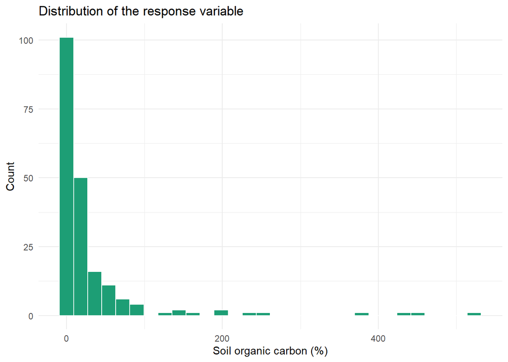

```r
ggplot(soc_clean, aes(x = soc_pct)) +
  geom_histogram(bins = 30, fill = "#1D9E75", color = "white") +
  labs(x = "Soil organic carbon (%)", y = "Count",
       title = "Distribution of the response variable") +
  theme_minimal()
```

### Task 2

Describe the distribution of `soc_pct`. Is it symmetric? Random forests are generally robust to skewed responses — note any concerns but proceed without transformation for now.

It is right skewed with many 0s and some really high values. The percent in the high values is over 100% which is suspicious.

## Predictor relationships

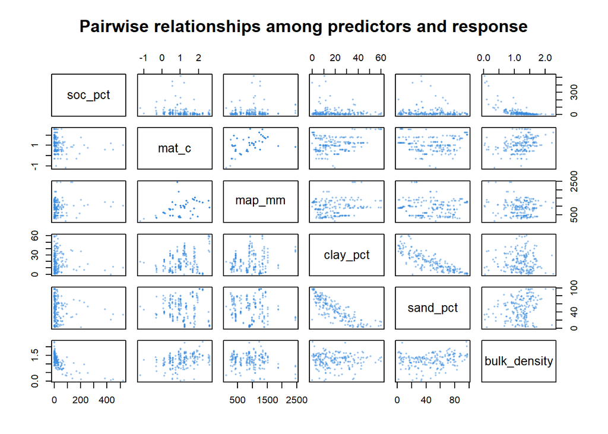

```r
soc_clean %>%
  select(soc_pct, mat_c, map_mm, clay_pct, sand_pct, bulk_density) %>%
  pairs(pch = 16, cex = 0.4, col = alpha("#378ADD", 0.5),
        main = "Pairwise relationships among predictors and response")
```

### Task 3

From the pairs plot, identify: (a) one predictor that appears to have a strong relationship with `soc_pct`, and (b) two predictors that are correlated with each other. Note: correlated predictors are handled differently by random forests than by linear models. We will return to this when we discuss variable importance.

1. bulk_density has a relationship with soc_pct
2. clay_pct and sand_pct are correlated, negatively.

# Fitting a Random Forest

## Train/test split

Before fitting any model, we set aside 20% of the data as a held-out test set. This test set will not be touched until the evaluation section.

```r
predictors <- c("mat_c", "map_mm", "clay_pct", "sand_pct", "bulk_density")
response   <- "soc_pct"

set.seed(605)
n      <- nrow(soc_clean)
test_i <- sample(seq_len(n), size = floor(0.2 * n))
train  <- soc_clean[-test_i, ]
test   <- soc_clean[ test_i, ]

cat("Training observations:", nrow(train), "\n")
```

```
## Training observations: 160
```

```r
cat("Test observations:    ", nrow(test),  "\n")
```

```
## Test observations:     40
```

## Fit the model

`ranger` is a fast C++ implementation of random forests. The key arguments are `num.trees` (number of trees; 500–1000 is usually sufficient), `mtry` (number of predictors randomly sampled at each split; default is p/3 for regression), `min.node.size` (minimum observations in a terminal node, controlling tree depth), `importance` (method for variable importance), and `keep.inbag = TRUE` which is required later for SHAP computation.

```r
rf_fit <- ranger(
  formula       = soc_pct ~ mat_c + map_mm + clay_pct + sand_pct + bulk_density,
  data          = train,
  num.trees     = 500,
  mtry          = 3,
  min.node.size = 5,
  importance    = "permutation",
  keep.inbag    = TRUE,
  seed          = 605
)
rf_fit
```

```
## Ranger result
##
## Call:
##  ranger(formula = soc_pct ~ mat_c + map_mm + clay_pct + sand_pct +      bulk_density, data = train, num.trees = 500, mtry = 3, min.node.size = 5,      importance = "permutation", keep.inbag = TRUE, seed = 605)
##
## Type:                             Regression
## Number of trees:                  500
## Sample size:                      160
## Number of independent variables:  5
## Mtry:                             3
## Target node size:                 5
## Variable importance mode:         permutation
## Splitrule:                        variance
## OOB prediction error (MSE):       1911.415
## R squared (OOB):                  0.6750602
```

### Task 4

Examine the `ranger` output. (a) What is the OOB prediction error (reported as MSE)? Convert it to RMSE and compare it to the standard deviation of `soc_pct` in the training set. A useful heuristic: RMSE / SD < 0.5 suggests reasonable predictive skill. (b) What is the OOB R²? How does “out-of-bag” differ from a held-out test set as a means of assessing model performance?

```r
RSME <- sqrt(1911.415)
RSME
```

```
## [1] 43.71973
```

```r
RSME/sd(train$soc_pct)
```

```
## [1] 0.5700348
```

1. The OOB prediction error is 1911.415. RSME is 43.71973. RSME / SD is 0.570038, so it fails the heuristic for reasonable predictive skill.
2. The OOB r2 is 0.6750602. The out of bag assesses the the fit of the training set. The held out set has not been used yet and is completely independent of the model itself.

## Hyperparameter tuning

The default `mtry = 3` may not be optimal for this dataset. The code below performs a simple grid search over all possible `mtry` values, using OOB error to evaluate each.

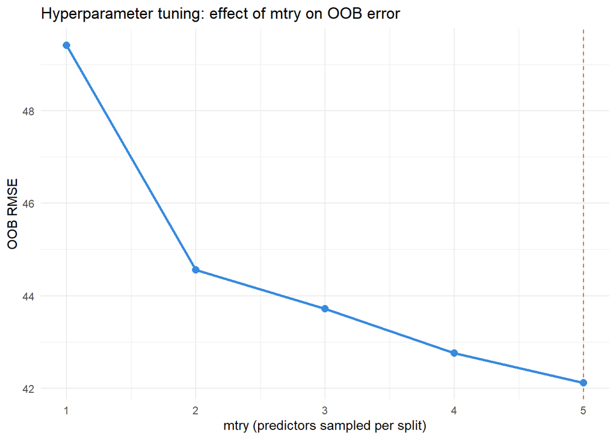

```r
mtry_vals  <- 1:length(predictors)
oob_errors <- numeric(length(mtry_vals))

for (i in seq_along(mtry_vals)) {
  fit_i <- ranger(
    formula    = soc_pct ~ mat_c + map_mm + clay_pct + sand_pct + bulk_density,
    data       = train,
    num.trees  = 500,
    mtry       = mtry_vals[i],
    keep.inbag = TRUE,
    seed       = 605
  )
  oob_errors[i] <- fit_i$prediction.error
}

data.frame(mtry = mtry_vals, oob_rmse = sqrt(oob_errors)) %>%
  ggplot(aes(x = mtry, y = oob_rmse)) +
  geom_line(color = "#378ADD", linewidth = 1) +
  geom_point(size = 2.5, color = "#378ADD") +
  geom_vline(xintercept = mtry_vals[which.min(oob_errors)],
             linetype = "dashed", color = "#D85A30") +
  labs(x = "mtry (predictors sampled per split)", y = "OOB RMSE",
       title = "Hyperparameter tuning: effect of mtry on OOB error") +
  theme_minimal()
```

### Task 5

1. What is the optimal `mtry` based on OOB error?

Based on OOB error, the optimal mtry is 5.

2. Refit the random forest using the optimal `mtry`, storing it as `rf_fit_tuned`. Evaluate it on the test set and compare test R² and RMSE to the default model. How much does performance change?

```r
rf_fit_tuned <- ranger(
  formula       = soc_pct ~ mat_c + map_mm + clay_pct + sand_pct + bulk_density,
  data          = train,
  num.trees     = 500,
  mtry          = 5,
  min.node.size = 5,
  importance    = "permutation",
  keep.inbag    = TRUE,
  seed          = 605
)
rf_fit_tuned
```

```
## Ranger result
##
## Call:
##  ranger(formula = soc_pct ~ mat_c + map_mm + clay_pct + sand_pct +      bulk_density, data = train, num.trees = 500, mtry = 5, min.node.size = 5,      importance = "permutation", keep.inbag = TRUE, seed = 605)
##
## Type:                             Regression
## Number of trees:                  500
## Sample size:                      160
## Number of independent variables:  5
## Mtry:                             5
## Target node size:                 5
## Variable importance mode:         permutation
## Splitrule:                        variance
## OOB prediction error (MSE):       1774.167
## R squared (OOB):                  0.6983923
```

```r
RSME <- sqrt(1774.167)
RSME
```

```
## [1] 42.12086
```

```r
RSME/sd(train$soc_pct)
```

```
## [1] 0.5491881
```

The performance is better, but the RSME/SD is still > 0.5.

3. Why is it acceptable to use OOB error for tuning `mtry` rather than needing a separate validation set?

It is acceptable because OOB acts like internal cross validation. It is computed from data not used in that tree and thus avoids some bias. The left out data is still available to use at the end.

# Variable Importance

## Permutation importance

Permutation importance measures how much prediction error increases when each predictor is randomly shuffled, breaking its relationship with the response. A large increase in error indicates that the predictor is important.

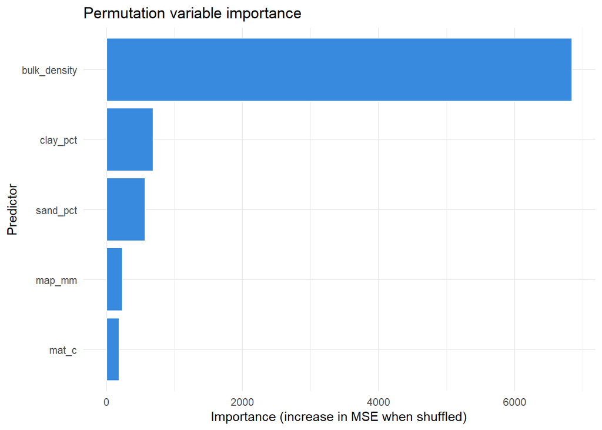

```r
vip(rf_fit,
    num_features = length(predictors),
    geom         = "col",
    aesthetics   = list(fill = "#378ADD", color = "white")) +
  labs(title = "Permutation variable importance",
       x = "Predictor", y = "Importance (increase in MSE when shuffled)") +
  theme_minimal()
```

### Task 6

Interpret the variable importance plot. (a) Which predictor has the highest importance? Does this match your expectation from the pairs plot (Task 3)?

bulk_density is the most important. This matches my answer to Task 3 where I noted its apparent relationship wiht the response variable.

2. `bulk_density` dominates both importance metrics. Is this ecologically meaningful, or does it suggest a potential problem? Consider: bulk density is known to be strongly negatively correlated with SOC (high organic matter soils tend to have low bulk density). Does this make bulk density a true *driver* of SOC, or more of a co-measurement of the same underlying property? Would you include it in a predictive model?

This fact leads me to believe that bulk_density is more of a co-measurment, so it is not well suited to predictive modeling or too well suited but misleading.

## Impurity-based importance

Permutation importance is generally the more reliable of the two importance methods. We can compare it to impurity-based importance (which measures how often each variable is used for splits, weighted by improvement) to see whether they agree.

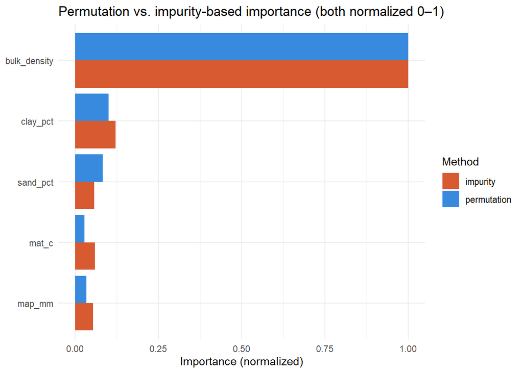

```r
rf_impurity <- ranger(
  formula    = soc_pct ~ mat_c + map_mm + clay_pct + sand_pct + bulk_density,
  data       = train,
  num.trees  = 500,
  mtry       = 3,
  importance = "impurity",
  seed       = 605
)

imp_perm     <- rf_fit$variable.importance
imp_impurity <- rf_impurity$variable.importance

data.frame(
  predictor   = names(imp_perm),
  permutation = imp_perm / max(imp_perm),
  impurity    = imp_impurity / max(imp_impurity)
) %>%
  pivot_longer(-predictor, names_to = "method", values_to = "importance") %>%
  mutate(predictor = fct_reorder(predictor, importance, .fun = max)) %>%
  ggplot(aes(x = importance, y = predictor, fill = method)) +
  geom_col(position = "dodge") +
  scale_fill_manual(values = c(permutation = "#378ADD", impurity = "#D85A30")) +
  labs(title = "Permutation vs. impurity-based importance (both normalized 0–1)",
       x = "Importance (normalized)", y = NULL, fill = "Method") +
  theme_minimal()
```

### Task 7

Do the two importance methods agree? If they disagree for any predictor, which method do you trust more and why? Note: impurity-based importance is known to be biased toward high-cardinality continuous variables (i.e., variables with a high percentage of unique values). Does that explain any discrepancy you see?

They generally agree on the order of predictors with bulk_density dominating. The permutation and impurity values are slightly different. In this case I would trust permutation based importance as the dataset is skewed with some unique values.

# Partial Dependence Plots

Variable importance tells us *that* a predictor matters, but not *how*. Partial dependence plots (PDPs) show the marginal effect of one predictor on the response, averaged over all other predictors. Note that `pdp::partial()` must be called with the package prefix since `purrr` (loaded as part of `tidyverse`) also has a `partial()` function.

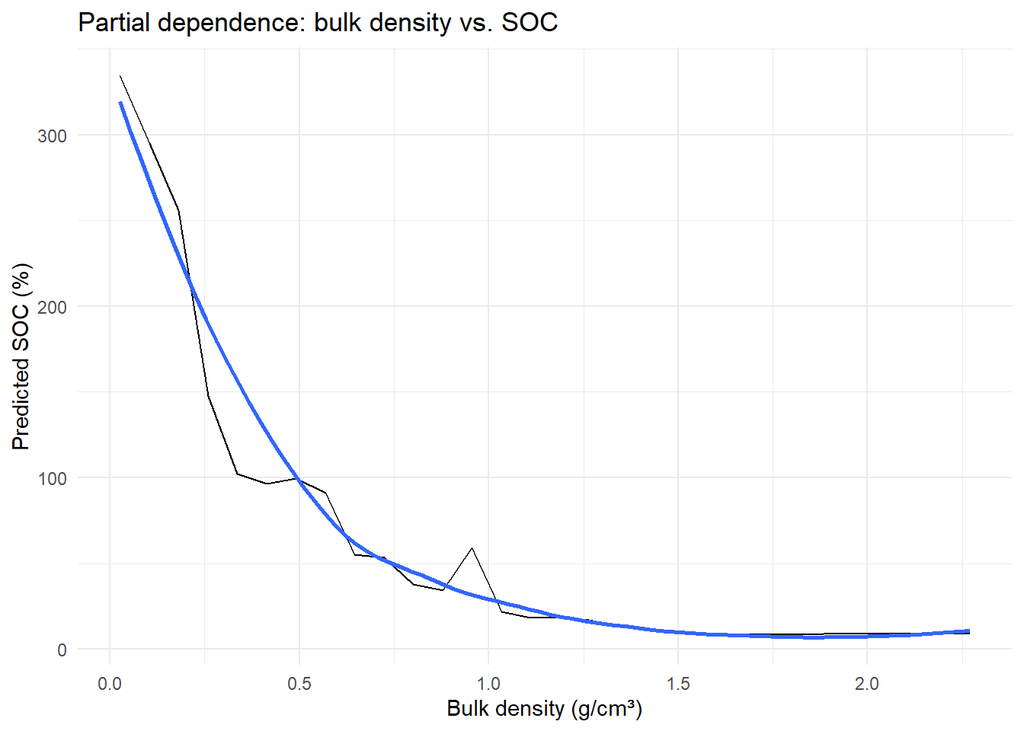

```r
pdp_top <- pdp::partial(
  rf_fit,
  pred.var        = "bulk_density",
  train           = train,
  grid.resolution = 30
)

autoplot(pdp_top, smooth = TRUE) +
  labs(x = "Bulk density (g/cm³)", y = "Predicted SOC (%)",
       title = "Partial dependence: bulk density vs. SOC") +
  theme_minimal()
```

### Task 8

Using the code above as a template, make PDP plots for two more predictors of your choice. For each of the three PDPs (including bulk density):

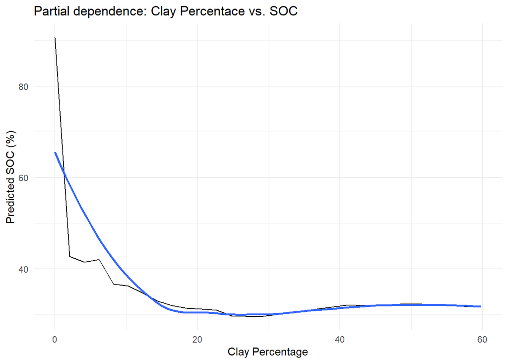

```r
pdp_top <- pdp::partial(
  rf_fit,
  pred.var        = "clay_pct",
  train           = train,
  grid.resolution = 30
)

autoplot(pdp_top, smooth = TRUE) +
  labs(x = "Clay Percentage", y = "Predicted SOC (%)",
       title = "Partial dependence: Clay Percentace vs. SOC") +
  theme_minimal()
```

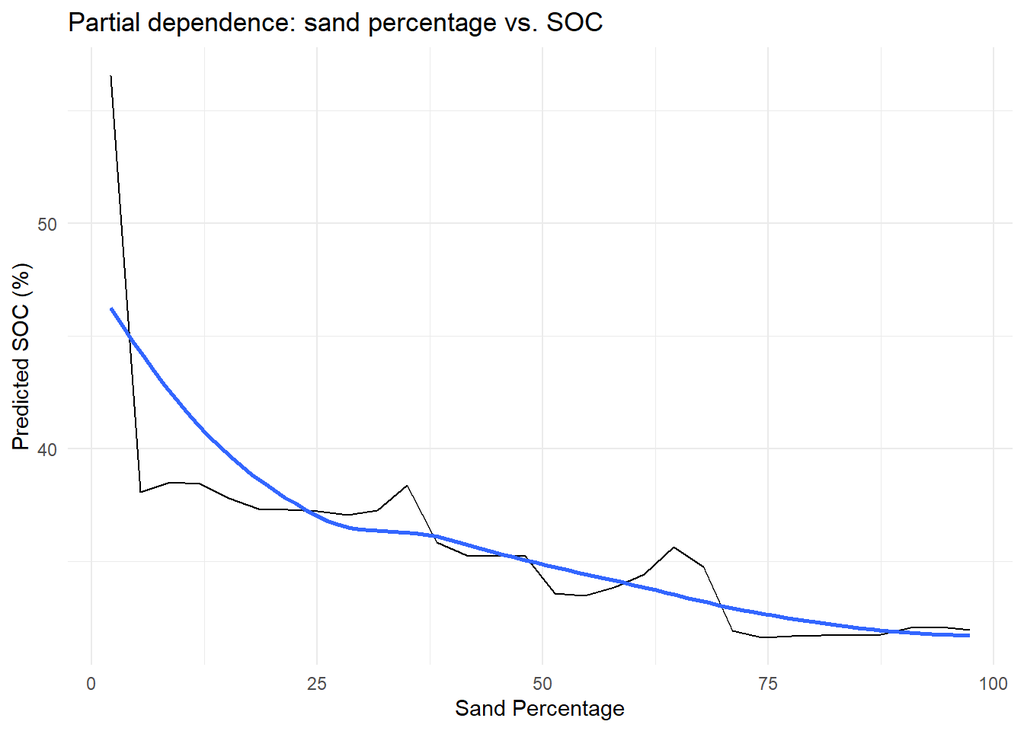

```r
pdp_top <- pdp::partial(
  rf_fit,
  pred.var        = "sand_pct",
  train           = train,
  grid.resolution = 30
)

autoplot(pdp_top, smooth = TRUE) +
  labs(x = "Sand Percentage", y = "Predicted SOC (%)",
       title = "Partial dependence: sand percentage vs. SOC") +
  theme_minimal()
```

1. describe the shape of the relationship (linear, unimodal, threshold, etc.), and

bulk density: non linear and convex. sand percentage: linear. outside of extreme low decreases at a linear rate. clay percentage: plateau, falls then holds.

2. describe where uncertainty is widest and why that might be.

bulk density: uncertainty is highest at low values < 0.5. sand percentage: high at low values < 25. localized uncertainty at medium values. ~30 and ~60 clay percentage: uncertainty at low values < 15.

## Two-way interaction PDP

PDPs can also visualize interactions between two predictors simultaneously. Two-predictor PDPs must be plotted with `ggplot` using `geom_tile()` rather than `autoplot()`.

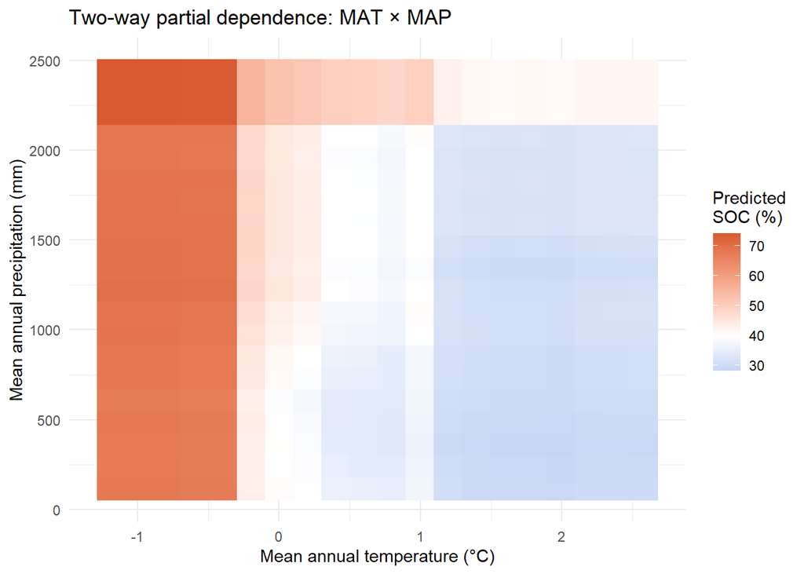

```r
pdp_2d <- pdp::partial(
  rf_fit,
  pred.var        = c("mat_c", "map_mm"),
  train           = train,
  grid.resolution = 20
)

ggplot(pdp_2d, aes(x = mat_c, y = map_mm, fill = yhat)) +
  geom_tile() +
  scale_fill_gradient2(low = "#378ADD", mid = "white", high = "#D85A30",
                       midpoint = median(pdp_2d$yhat)) +
  labs(x = "Mean annual temperature (°C)", y = "Mean annual precipitation (mm)",
       fill = "Predicted\nSOC (%)", title = "Two-way partial dependence: MAT × MAP") +
  theme_minimal()
```

### Task 9

Using the two-way PDP above as a template, generate a two-way PDP for `bulk_density` and `mat_c`. Does the effect of bulk density on SOC appear to depend on temperature, or is it consistent across the temperature gradient?

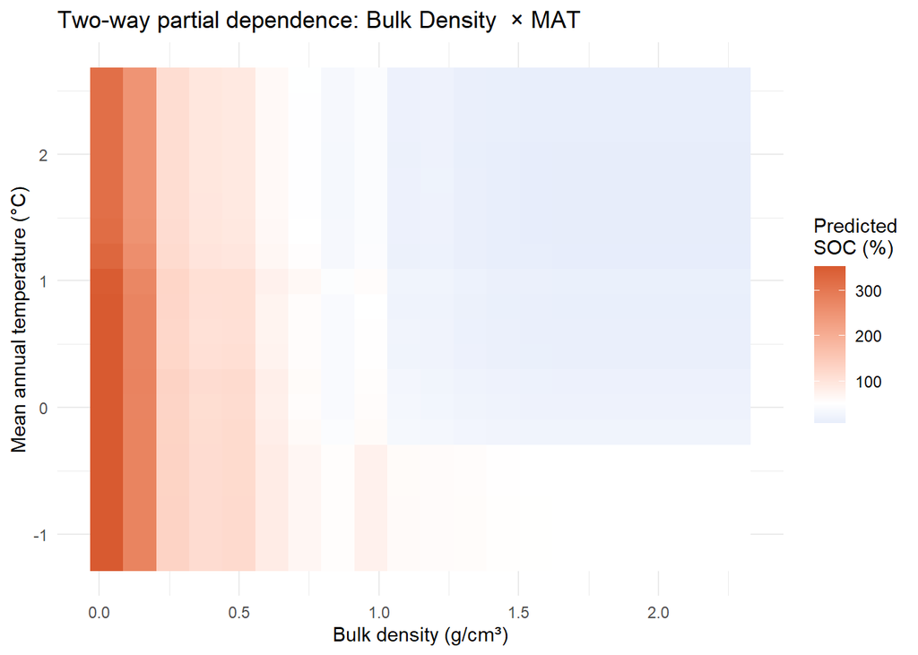

```r
pdp_2d <- pdp::partial(
  rf_fit,
  pred.var        = c("bulk_density", "mat_c"),
  train           = train,
  grid.resolution = 20
)

ggplot(pdp_2d, aes(x = bulk_density, y = mat_c, fill = yhat)) +
  geom_tile() +
  scale_fill_gradient2(low = "#378ADD", mid = "white", high = "#D85A30",
                       midpoint = median(pdp_2d$yhat)) +
  labs(x = "Bulk density (g/cm³)", y = "Mean annual temperature (°C)",
       fill = "Predicted\nSOC (%)", title = "Two-way partial dependence: Bulk Density  × MAT") +
  theme_minimal()
```

It does not look like the effect of bulk density is dependent on air temperature. By far the most variation is along the x axis. Temperature may have a slight effect at high bulk density.

# Evaluating on the Test Set

Now we use the held-out test set for an honest estimate of generalization performance. We save the predicted vs. observed plot as `p_rf_obs` so we can reuse it alongside the LMM plot in the next section.

```r
test_preds <- predict(rf_fit, data = test)$predictions

rmse <- sqrt(mean((test_preds - test$soc_pct)^2))
mae  <- mean(abs(test_preds - test$soc_pct))
r2   <- cor(test_preds, test$soc_pct)^2

cat("Test set performance\n")
```

```
## Test set performance
```

```r
cat("--------------------\n")
cat(sprintf("RMSE: %.3f\n", rmse))
```

```
## RMSE: 34.847
```

```r
cat(sprintf("MAE:  %.3f\n", mae))
```

```
## MAE:  18.575
```

```r
cat(sprintf("R²:   %.3f\n", r2))
```

```
## R²:   0.460
```

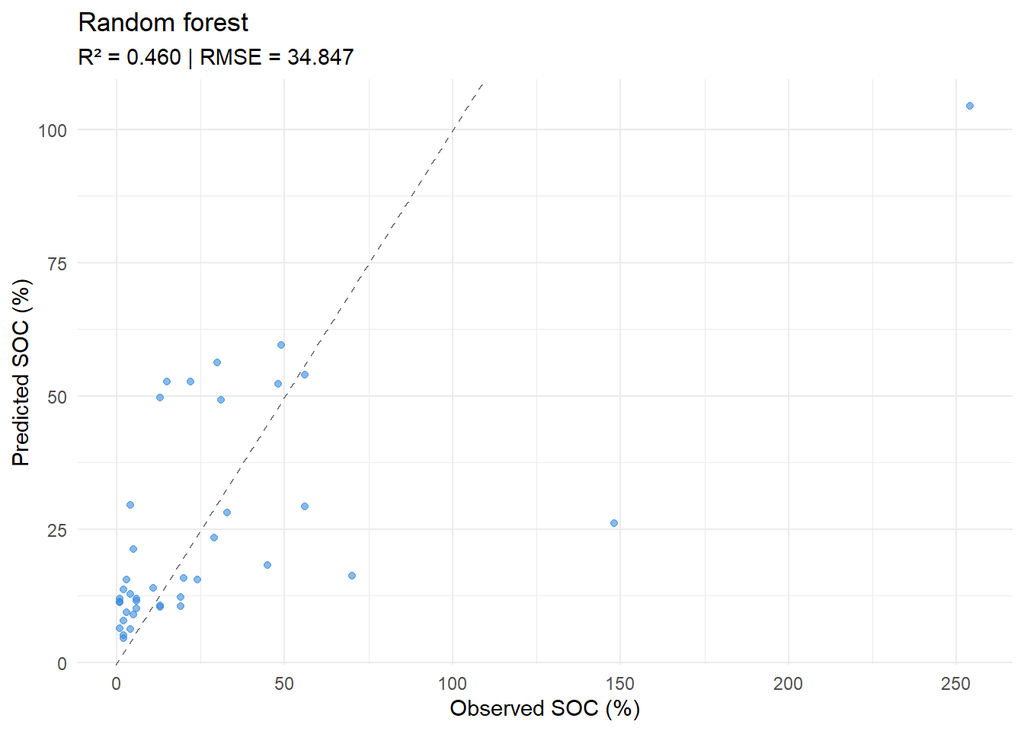

```r
p_rf_obs <- data.frame(observed = test$soc_pct, predicted = test_preds) %>%
  ggplot(aes(x = observed, y = predicted)) +
  geom_point(alpha = 0.6, color = "#378ADD") +
  geom_abline(slope = 1, intercept = 0, linetype = "dashed", color = "grey40") +
  labs(x = "Observed SOC (%)", y = "Predicted SOC (%)",
       title = "Random forest",
       subtitle = sprintf("R² = %.3f | RMSE = %.3f", r2, rmse)) +
  theme_minimal()

p_rf_obs
```

### Task 10

1. Compare the test set R² to the OOB R² from the model fit above. Are they similar? If the test R² is substantially lower, what might explain the gap?

2. Are there systematic patterns in the residuals, i.e., does the model consistently over- or under-predict at certain SOC values?

The model predicts above and below the 1:1 line. There are more overpredictions at low SOC and more underpredictions at high SOC values.

# Comparison to a Linear Mixed Model

Comparing an ML model to a simpler baseline is one of the most informative things we can do. Here we fit a linear mixed model with `site_id` as a random effect, the same structure you explored earlier in the course. Because our predictors are on very different scales (`map_mm` ranges from ~100 to 2400 while `bulk_density` ranges from ~0 to 2), we rescale before fitting. Note that we did not need to do this for the random because random forests are scale-invariant (they only use the rank order of splits). Linear models are not, because coefficients depend directly on the units of the predictors.

```r
train_scaled <- train %>% mutate(across(all_of(predictors), scale))
test_scaled  <- test  %>% mutate(across(all_of(predictors), scale))

lmm_fit <- lmer(
  soc_pct ~ mat_c + map_mm + clay_pct + sand_pct + bulk_density + (1 | site_id),
  data = train_scaled,
  REML = FALSE
)
summary(lmm_fit)
```

```
## Linear mixed model fit by maximum likelihood . t-tests use Satterthwaite's
##   method [lmerModLmerTest]
## Formula: soc_pct ~ mat_c + map_mm + clay_pct + sand_pct + bulk_density +
##     (1 | site_id)
##    Data: train_scaled
##
##       AIC       BIC    logLik -2*log(L)  df.resid
##    1731.6    1756.2    -857.8    1715.6       152
##
## Scaled residuals:
##     Min      1Q  Median      3Q     Max
## -2.4198 -0.4896 -0.0295  0.2864  4.7312
##
## Random effects:
##  Groups   Name        Variance Std.Dev.
##  site_id  (Intercept)  817     28.58
##  Residual             2108     45.92
## Number of obs: 160, groups:  site_id, 43
##
## Fixed effects:
##              Estimate Std. Error       df t value Pr(>|t|)
## (Intercept)   32.3030     5.8176  33.8584   5.553 3.33e-06 ***
## mat_c         12.7010     6.6389  53.3521   1.913   0.0611 .
## map_mm        -0.6132     6.3305  40.8477  -0.097   0.9233
## clay_pct     -45.3636     9.3306 135.6839  -4.862 3.17e-06 ***
## sand_pct     -40.9863     9.6316 111.7550  -4.255 4.36e-05 ***
## bulk_density -51.5503     4.9309 158.5910 -10.455  < 2e-16 ***
## ---
## Signif. codes:  0 '***' 0.001 '**' 0.01 '*' 0.05 '.' 0.1 ' ' 1
##
## Correlation of Fixed Effects:
##             (Intr) mat_c  map_mm cly_pc snd_pc
## mat_c        0.008
## map_mm       0.005 -0.397
## clay_pct     0.007 -0.234 -0.078
## sand_pct    -0.014 -0.155 -0.049  0.811
## bulk_densty  0.020 -0.267  0.242 -0.243 -0.330
```

```r
lmm_preds <- predict(lmm_fit, newdata = test_scaled, allow.new.levels = TRUE)
lmm_rmse  <- sqrt(mean((lmm_preds - test$soc_pct)^2))
lmm_r2    <- cor(lmm_preds, test$soc_pct)^2

cat("Model comparison (test set)\n")
```

```
## Model comparison (test set)
```

```r
cat("---------------------------\n")
cat(sprintf("Random forest — RMSE: %.3f | R²: %.3f\n", rmse, r2))
```

```
## Random forest — RMSE: 34.847 | R²: 0.460
```

```r
cat(sprintf("Linear LMM    — RMSE: %.3f | R²: %.3f\n", lmm_rmse, lmm_r2))
```

```
## Linear LMM    — RMSE: 44.914 | R²: 0.409
```

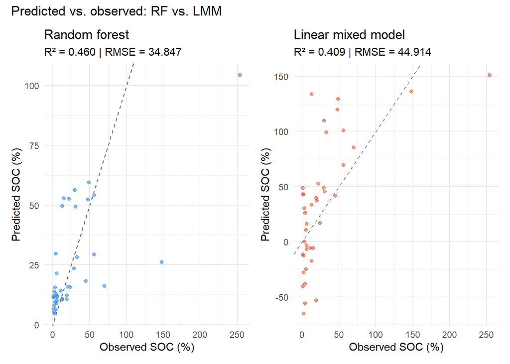

```r
p_lmm_obs <- data.frame(observed = test$soc_pct, predicted = lmm_preds) %>%
  ggplot(aes(x = observed, y = predicted)) +
  geom_point(alpha = 0.6, color = "#D85A30") +
  geom_abline(slope = 1, intercept = 0, linetype = "dashed", color = "grey40") +
  labs(x = "Observed SOC (%)", y = "Predicted SOC (%)",
       title = "Linear mixed model",
       subtitle = sprintf("R² = %.3f | RMSE = %.3f", lmm_r2, lmm_rmse)) +
  theme_minimal()

p_rf_obs + p_lmm_obs +
  plot_annotation(title = "Predicted vs. observed: RF vs. LMM")
```

### Task 11

1. What is the test set performance of each model?

Random Forest: better at RMSE: 34.847 | R²: 0.460 Linear LMM: Slightly worse at RMSE: 44.914 | R²: 0.409

2. Do LMM assumptions appear to be met based on your exploration of the data above?

LMM assumptions are not met. Task 8 showed that the relationship between some variables are non linear. Also, clay and sand are highly correlated.

3. Under what circumstances might you choose the RF over the LMM, or vice versa? Note: the regularization that keeps the LMM from overfitting (REML shrinkage on random effects) is analogous to the regularization penalty in LASSO/ridge regression. The random forest achieves implicit regularization through bagging and random feature selection.

With this note in mind, I would choose RF when I suspect more non linear relationships and want the best test set performance. I might choose LMM when I want to understand predictor relationships with more certainty, but that may be due to my relative lack of experience with RF.

# SHAP Values

## Global vs. local interpretation

Before computing SHAP values, it is worth being precise about what question we are asking.

| Level | Question | Method |
| --- | --- | --- |
| **Global** | Which predictors matter most, on average? | Variable importance, PDPs |
| **Global** | What is the average effect of predictor X? | Partial dependence plot |
| **Local** | Why did the model make *this* prediction? | SHAP waterfall plot |
| **Local → Global** | How does X affect predictions across all observations? | SHAP beeswarm / dependence plot |

## Fit a gradient boosted model

We also fit an `xgboost` model on the same training data so we can compare SHAP values across two different algorithms and test whether our ecological conclusions depend on algorithm choice.

```r
X_train <- train %>% select(all_of(predictors)) %>% as.matrix()
y_train <- train[[response]]
X_test  <- test  %>% select(all_of(predictors)) %>% as.matrix()

xgb_fit <- xgboost(
  x                = X_train,
  y                = y_train,
  nrounds          = 300,
  max_depth        = 4,
  learning_rate    = 0.05,
  subsample        = 0.8,
  colsample_bytree = 0.8,
  objective        = "reg:squarederror"
)
```

## Compute SHAP values

```r
ks_rf    <- kernelshap(rf_fit,  X = train[, predictors], bg_X = train[, predictors])
```

```
## Exact Kernel SHAP values
```

[output not shown]

```r
shap_rf  <- shapviz(ks_rf)

ks_xgb   <- kernelshap(xgb_fit, X = X_train, bg_X = X_train)
```

```
## Exact Kernel SHAP values
```

[output not shown]

```r
shap_xgb <- shapviz(ks_xgb)
```

The efficiency property of Shapley values guarantees that the SHAP values for all predictors sum exactly to (prediction − baseline) for every observation. The code below verifies this holds for our model: a maximum discrepancy of zero confirms the SHAP values are internally consistent and that credit for each prediction has been fully and fairly distributed across predictors.

```r
shap_sum <- rowSums(shap_rf$S) + shap_rf$baseline
rf_preds <- predict(rf_fit, data = train)$predictions
cat(sprintf("Max discrepancy between SHAP sum and prediction: %.6f\n",
            max(abs(shap_sum - rf_preds))))
```

```
## Max discrepancy between SHAP sum and prediction: 0.000000
```

## Global SHAP importance

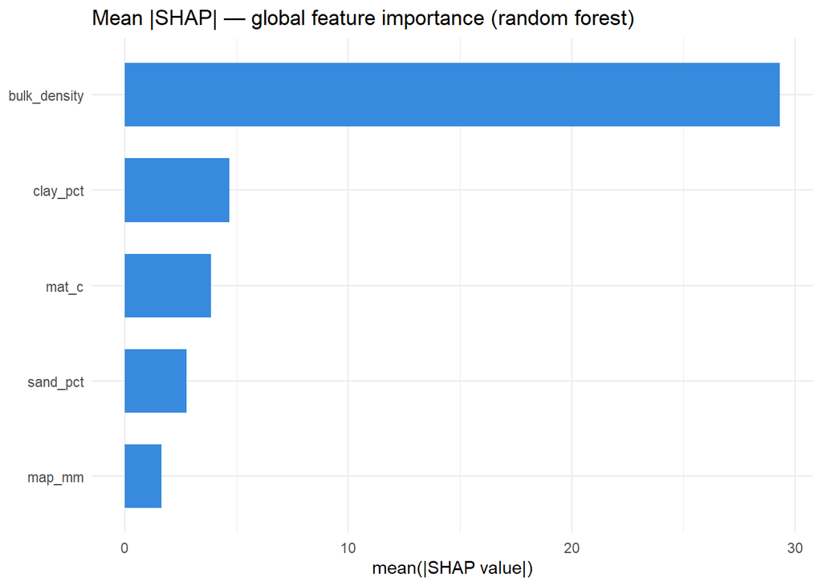

```r
sv_importance(shap_rf, kind = "bar", fill = "#378ADD") +
  labs(title = "Mean |SHAP| — global feature importance (random forest)") +
  theme_minimal()
```

### Task 12

Compare this SHAP importance ranking to the permutation importance ranking from Task 6. Do they agree? If any predictors change rank substantially, note which ones and suggest why. Think about how correlated predictors are handled differently by permutation importance vs. SHAP.

## SHAP beeswarm plot

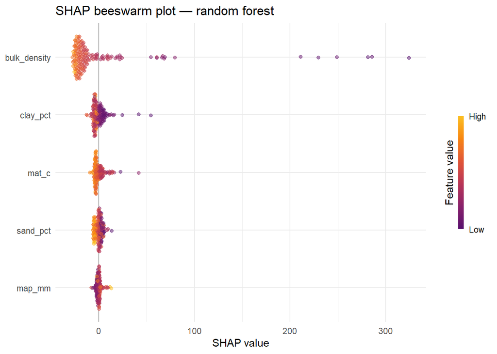

```r
sv_importance(shap_rf, kind = "beeswarm", alpha = 0.5) +
  labs(title = "SHAP beeswarm plot — random forest") +
  theme_minimal()
```

### Task 13

Using `sv_importance()` with `kind = "beeswarm"`, generate the equivalent beeswarm plot for the `xgboost` model (`shap_xgb` is already computed above). Use `patchwork` to place both plots side by side, then describe any differences in the direction or magnitude of effects between the two models.

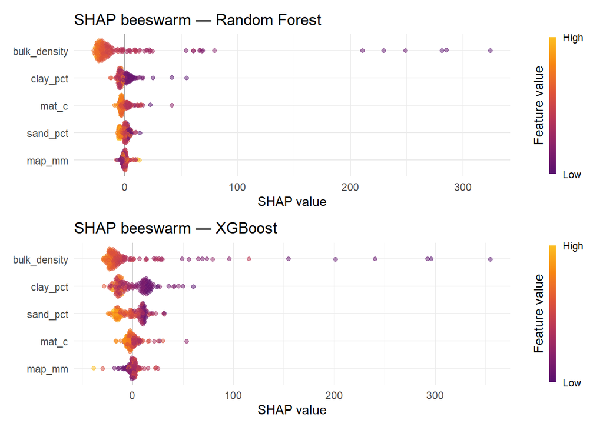

```r
p_rf <- sv_importance(shap_rf, kind = "beeswarm", alpha = 0.5) +
  labs(title = "SHAP beeswarm — Random Forest") +
  theme_minimal()

p_xgb <- sv_importance(shap_xgb, kind = "beeswarm", alpha = 0.5) +
  labs(title = "SHAP beeswarm — XGBoost") +
  theme_minimal()

p_rf / p_xgb
```

Sand and clay percentage have different groupings between the two models. In the XGBoost they have far more magnitude than the base.

# Local Interpretation

The beeswarm plot gives us a global picture. The **waterfall plot** explains a single prediction — why did the model predict what it did for this specific observation?

```r
ks_rf_test   <- kernelshap(rf_fit, X = test[, predictors], bg_X = train[, predictors])
```

```
## Exact Kernel SHAP values
```

[output not shown]

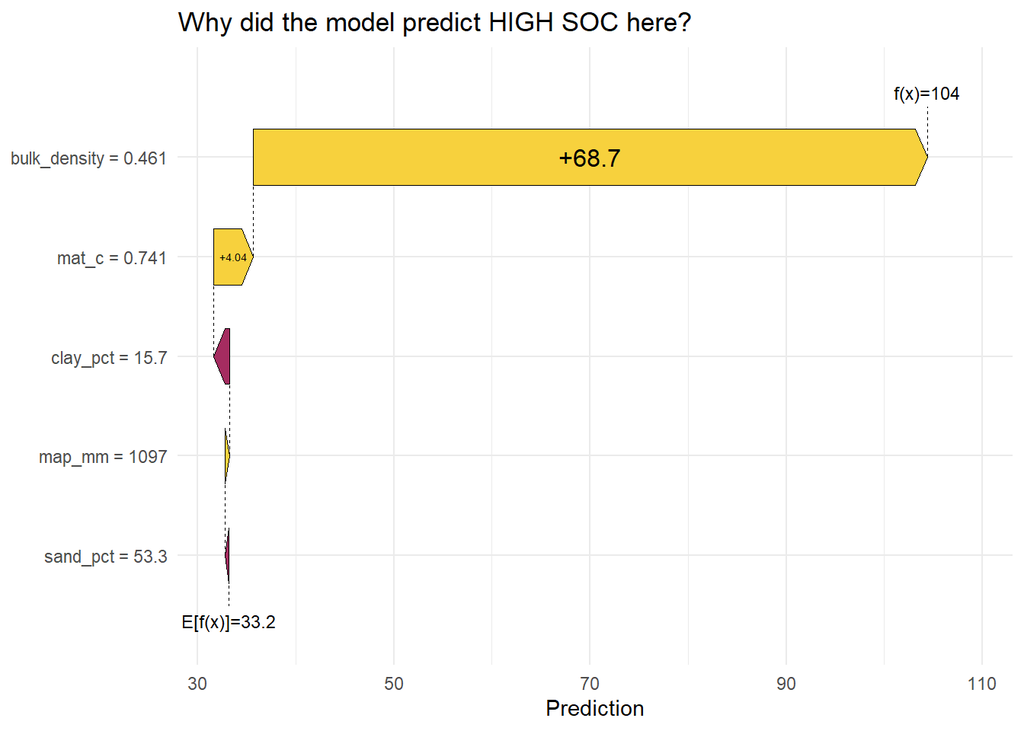

```r
shap_rf_test <- shapviz(ks_rf_test)

test_preds2 <- predict(rf_fit, data = test)$predictions
high_soc_i  <- which.max(test_preds2)
low_soc_i   <- which.min(test_preds2)

sv_waterfall(shap_rf_test, row_id = high_soc_i) +
  labs(title = "Why did the model predict HIGH SOC here?") +
  theme_minimal()
```

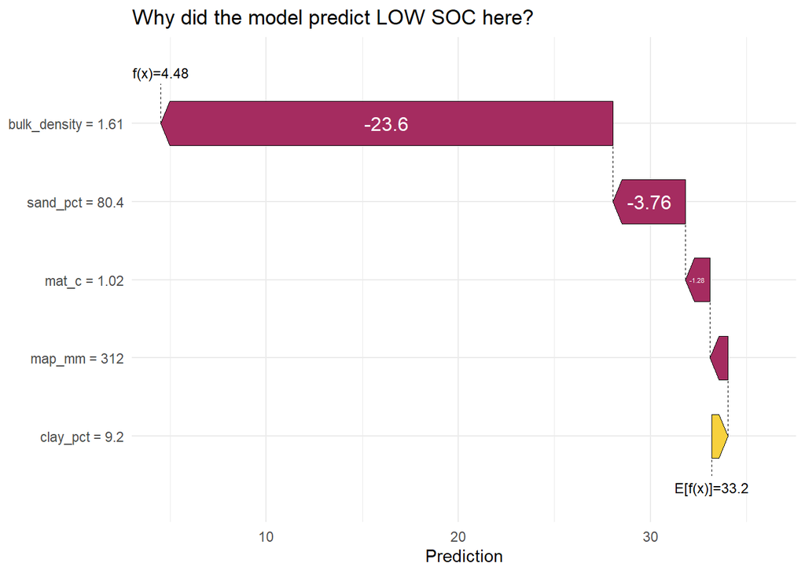

```r
sv_waterfall(shap_rf_test, row_id = low_soc_i) +
  labs(title = "Why did the model predict LOW SOC here?") +
  theme_minimal()
```

```r
cat("High SOC observation predictor values:\n")
```

```
## High SOC observation predictor values:
```

```r
print(test[high_soc_i, predictors])
```

```
## # A tibble: 1 × 5
##   mat_c map_mm clay_pct sand_pct bulk_density
##   <dbl>  <dbl>    <dbl>    <dbl>        <dbl>
## 1 0.741   1097     15.7     53.3        0.461
```

```r
cat("\nLow SOC observation predictor values:\n")
```

```
##
## Low SOC observation predictor values:
```

```r
print(test[low_soc_i, predictors])
```

```
## # A tibble: 1 × 5
##   mat_c map_mm clay_pct sand_pct bulk_density
##   <dbl>  <dbl>    <dbl>    <dbl>        <dbl>
## 1  1.02    312      9.2     80.4         1.61
```

### Task 14

1. For each waterfall plot, which predictors contributed to pushing the prediction above the baseline vs. below?

bulk density was the most responsible for pushing the predictions. With low bulk densities pushing it up and high pushing it down. The high SOC was pushed next by mat_c. The low was pushed by sand_pct and then mat_c.

2. Choose two intermediate SOC points from the dataset and make waterfall plots for them. How do the predictor contributions compare with the high and low SOC waterfall plots?

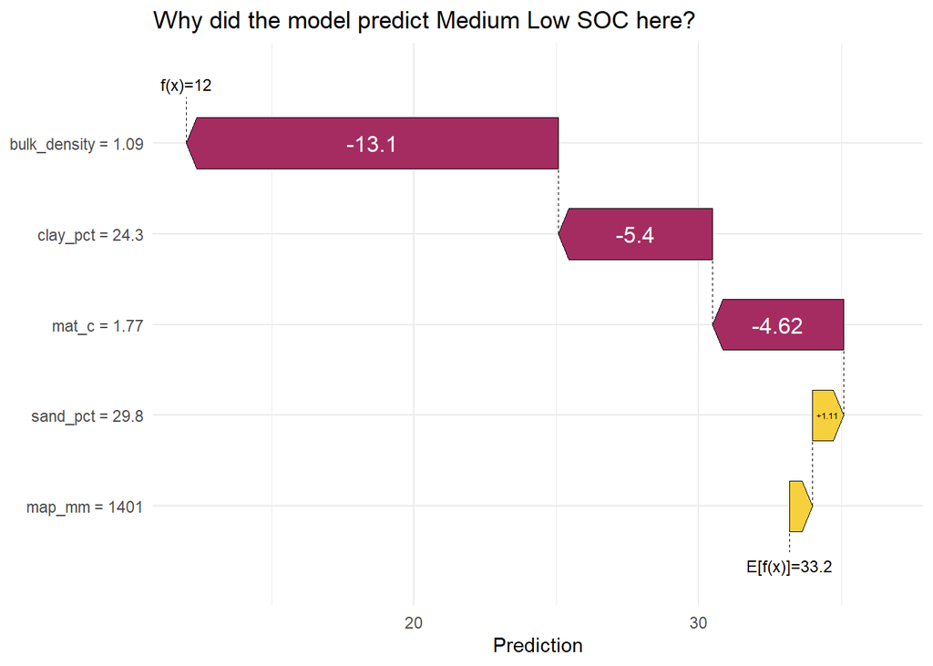

```r
ord <- order(test_preds2)

mid1_i <- ord[round(length(ord) * 0.4)]
mid2_i <- ord[round(length(ord) * 0.6)]



sv_waterfall(shap_rf_test, row_id = mid1_i) +
  labs(title = "Why did the model predict Medium Low SOC here?") +
  theme_minimal()
```

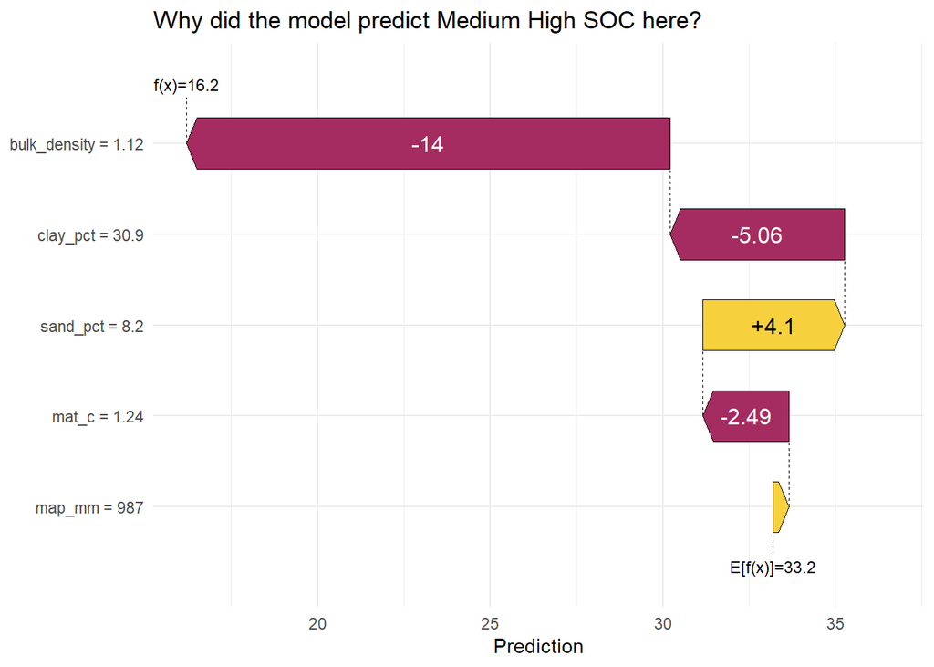

```r
sv_waterfall(shap_rf_test, row_id = mid2_i) +
  labs(title = "Why did the model predict Medium High SOC here?") +
  theme_minimal()
```

These medium values have more complex predictor relationships. bulk_density still dominates, but the other predictors are responsible for much more of the predicted SOC. clay_pct, sand_pct, and mat_c have proportionally large effects.